# Part II - (Influence of Loan Variables on Loan Amount)

## by (Oluwatuyi Olawale)

## Investigation Overview

> The exploration examined the influence of customer loan variables on Loan Amount. Specifically, the analysis explores selected customers loan information on amount of loan recieved by the customer. The main variables of focus are: Credit Score Range (lower and upper)', LoanTerm, Borrower Rate and StatedMonthly Income.

## Dataset Overview

> The dataset contains 113,937 loans with 81 variables on each loan. The needed variables were extracted from the dataset before exploration. The credit score column was also generated by averaging the credit score range (lower and upper).

### (Distribution of Loan Original Amount )

Loan Original Amount plotted on a log scale. It is multi-modal and slightly skewed to the right. The most common Original Loan amount occuring around 5000 dollars, while others occured at around 10,000 and slightly above 15000 dollars.

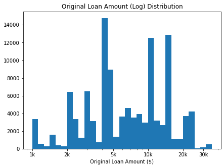

### (Correlation Between LoanOriginalAmount, BorrowerRate, StatedMonthlyIncome, and CreditScore)

A heat map plotted to show the correlation between LoanOriginalAmount. A positive correlation between LoanOriginal Amount and Stated Monthly Income and Credit Score but a negative correlation between Loan Amount and Borrowers' Interest Rate.

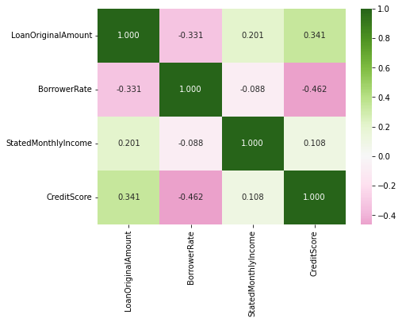

### (Relationship between Loan Original Amount vs VerfiableIncome and LoanTerm)

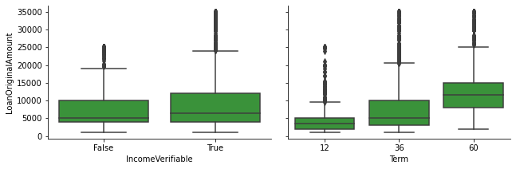

### OriginalLoanAmount vs BorrowerRate by Loan Term

A categorical scatterplot to show the relationship between Original Loan Amount and Borrower Rate (Interest Rate) while considering Loan Term. It is obvious that loan term is associated with interest rate. 12 months term loans recieved the lowest interest rates while 60months loan terms get higher interest rate at increased loan amount. Interestingly, there are some small original loan amount that recieved high interest rate without considering the loan terms.

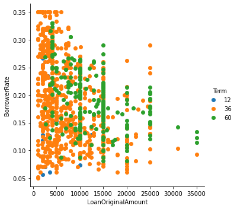

### OriginalLoanAmount vs StatedMonthlyIncome by Credit Score

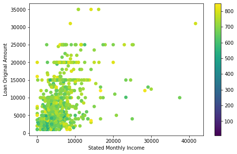